# Apuntes Presentación

19-09-2020

```r
# Librerías usadas
library(tidyverse)
library(caret)
```

# Claudia:

Variables de interés:

- number_of_elements (train)
- range_fie (train)
- std_ThermalConductivity (train)
- O (unique_m)
- Cu (unique_m)
- Ba (unique_m)
- Variable respuesta: critical_temp (“key” para relacionar las bases)

# Jeremías:

# Relacionar Bases de Datos

```r
library(tidyverse)

train = read.csv("train.csv", header = TRUE)
unique_m = read.csv("unique_m.csv", header = TRUE)
train$critical_temp = NULL
unique_m$material = NULL # Variable cualitativa nominal
df = data.frame(train, unique_m)

attach(df)
variables = names(df)
cantvariables = length(variables)

print(paste("Hay ", cantvariables," variables", sep=""))
```

```
## [1] "Hay 168 variables"
```

> En este caso da lo mismo el “Join” para relacionar las bases, ya que no hay datos faltantes y ambas bases tienen 21263 datos.

# Limpieza de base

- Eliminar datos que varían muy poco (No son explicativas)

```r
variables_baja_var = nearZeroVar(df, names = TRUE) # Explicar

for(i in 1:(length(variables_baja_var))){
    a = paste("df$",variables_baja_var[i],"=NULL",sep = "")
    eval(parse( text=a ))
}
variables = names(df)
cantvariables = length(variables)

print(paste("Quedan ", cantvariables," variables", sep=""))
```

```
## [1] "Quedan 87 variables"
```

- Eliminar variables con correlación muy baja respecto a $critical\_temp$ ($|cor| < 0.05$)

```r
tol = 0.05
cor_baja = c()
for(i in 1:(cantvariables-1)){
    correlacion = cor(df[,i], df$critical_temp)
    if(abs(correlacion) < tol){
        cor_baja = c(cor_baja, i)
    }
}

variables_cor_baja = c()
for(i in 1:(length(cor_baja))){
    variables_cor_baja = c(variables_cor_baja, variables[cor_baja[i]])
}

for(i in 1:(length(variables_cor_baja))){
    a = paste("df$",variables_cor_baja[i],"=NULL",sep = "")
    eval(parse( text=a ))
}

variables = names(df)
cantvariables = length(variables)

print(paste("Quedan ", cantvariables," variables", sep=""))
```

```
## [1] "Quedan 86 variables"
```

- Eliminar variables muy correlacionadas entre si ($|cor| > 0.8$)

```r
tol = 0.8
cor_alta = c()
for( i in 1:(cantvariables-1)){
    if(i != cantvariables-1){
        for(j in (i+1):(cantvariables-1)){
            correlacion = cor(df[,i], df[,j])
            if(abs(correlacion) > tol){
                cor_alta = c(cor_alta,j)
            }
        }
    }
}

cor_alta = sort(cor_alta[!duplicated(cor_alta)])

variables_cor_alta = c()
for(i in 1:(length(cor_alta))){
    variables_cor_alta = c(variables_cor_alta, variables[cor_alta[i]])
}

for(i in 1:(length(variables_cor_alta))){
    a = paste("df$",variables_cor_alta[i],"=NULL",sep = "")
    eval(parse( text=a ))
}

attach(df)
variables = names(df)
cantvariables = length(variables)

print(paste("Quedaron ", cantvariables," variables", sep=""))
```

```
## [1] "Quedaron 34 variables"
```

> De 168 variables pasamos a 34!!
- Eliminar datos duplicados

```r
df = df[!duplicated(df),]
```

> Se eliminaron 56 datos duplicados

# Richi:

# Elegir variables a través de su correlación con la variable respuesta (critical_temp)

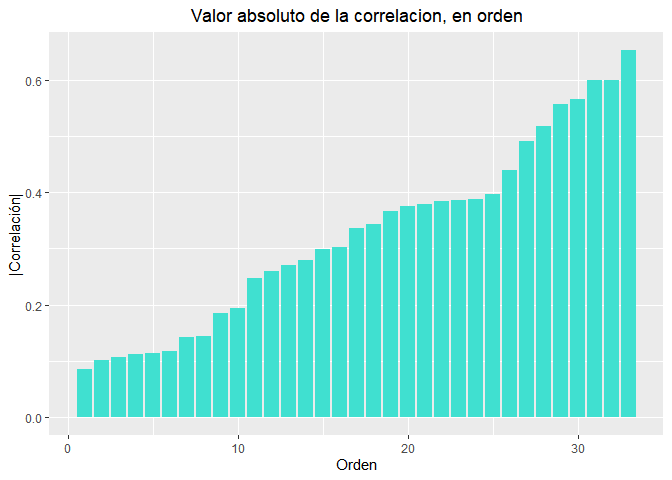

```r
correlaciones = cor(df)[,34][1:33]
indicesg1 = seq(1,33)
cor_ord = sort(abs(correlaciones))
ic = which(abs(correlaciones) >= 0.6)
variables_cor = c()

grafico1 = data.frame(indicesg1, cor_ord)


ggplot(data = grafico1) +
    geom_col(mapping = aes(x= indicesg1, y = cor_ord), fill = "turquoise") +
    xlab("Orden") +
    ylab("|Correlación|") +
    ggtitle("Valor absoluto de la correlacion, en orden") +
    theme(plot.title = element_text(hjust = 0.5)) +



for(i in 1:(length(ic))){
    variables_cor = c(variables_cor, variables[ic[i]])
}
```

```r
variables_cor
```

```
## [1] "number_of_elements"      "range_fie"
## [3] "std_ThermalConductivity"
```

# Creación de los modelos a partir de correlación más alta: *std_ThermalConductivity*

```r
modelo = lm(formula = critical_temp ~ std_ThermalConductivity, data = df )
(R2 = 1 - sum((modelo$fitted.values - df$critical_temp)^2)/sum((df$critical_temp - mean(df$critical_temp))^2))
```

```
## [1] 0.4267945
```

> R2 muy bajo aunque esperado por ser un modelo lineal simple.
- Valores reales vs predichos:

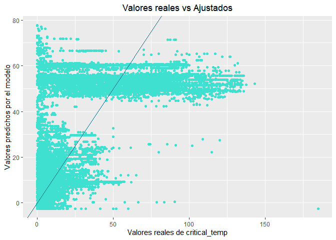

```r
v1 = df$critical_temp; v2 = modelo$fitted.values
grafico2 = data.frame(v1, v2)

ggplot(data = grafico2) +
    geom_point(mapping = aes(x = v1, y = v2), color = "turquoise") +
    geom_abline(slope = 1, intercept = 0, color = "deepskyblue4") +
    ggtitle("Valores reales vs Ajustados") +
    theme(plot.title = element_text(hjust = 0.5)) +
    xlab("Valores reales de critical_temp") +
    ylab("Valores predichos por el modelo")
```

# Esteban:

# Plantear un nuevo modelo con las herramientas que tenemos, para intentar obtener mejores regresiones.

- Creamos gráficos agrupando por *number_of_elements* (variable cuant. discreta)

```r
summary(df$number_of_elements)
```

```
##    Min. 1st Qu.  Median    Mean 3rd Qu.    Max.
##    1.00    3.00    4.00    4.12    5.00    9.00
```

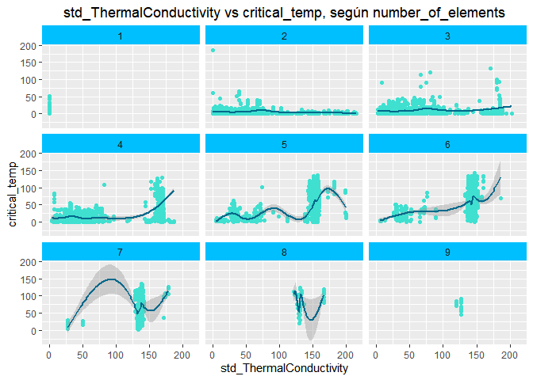

```r
# Wrap 1: std_ThermalConductivity vs critical_temp grouped by number_of_elements
ggplot(data=df, mapping = aes(x = std_ThermalConductivity, y = critical_temp)) +
    geom_point(color = "turquoise") +
    geom_smooth(color = "deepskyblue4") +
    facet_wrap(~ number_of_elements, nrow = 3) +
    theme(strip.background = element_rect(fill="deepskyblue1")) +
    ggtitle("std_ThermalConductivity vs critical_temp, según number_of_elements") +
    theme(plot.title = element_text(hjust = 0.5))
```

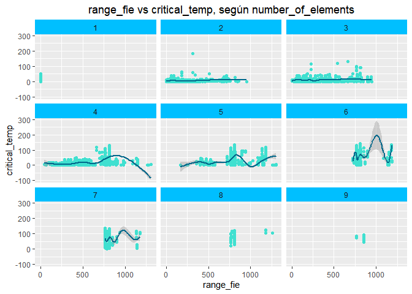

```r
# Wrap 2: range_fie vs critical_temp wrapped by number_of_elements
ggplot(data=df, mapping = aes(x = range_fie, y = critical_temp)) +
    geom_point(color = "turquoise") +
    geom_smooth(color = "deepskyblue4") +
    facet_wrap(~ number_of_elements, nrow = 3) +
    theme(strip.background = element_rect(fill="deepskyblue1")) +
    ggtitle("range_fie vs critical_temp, según number_of_elements") +
    theme(plot.title = element_text(hjust = 0.5))
```

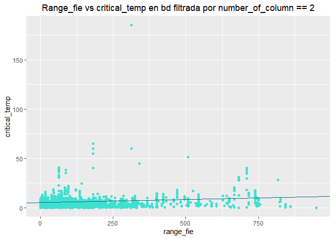

```r
modelos = list()

for(i in 1:9){
    ndf = df[df$number_of_elements == i,]
    a = paste("modelos[['n",i,"']]=lm(ndf$critical_temp ~ ndf$range_fie)",sep = "")
    eval(parse( text=a ))
}

ndf = df[df$number_of_elements == 2,]

ggplot(data = ndf) +
    geom_point(mapping = aes(x = ndf$range_fie, y = ndf$critical_temp) ,color = "turquoise")+
    geom_abline(mapping = aes(intercept = modelos$n2$coefficients[1], slope = modelos$n3$coefficients[2]), color = "deepskyblue4") +
    ggtitle("Range_fie vs critical_temp en bd filtrada por number_of_column == 2") +
    theme(plot.title = element_text(hjust = 0.5)) +
    xlab("range_fie") +
    ylab("critical_temp")
```

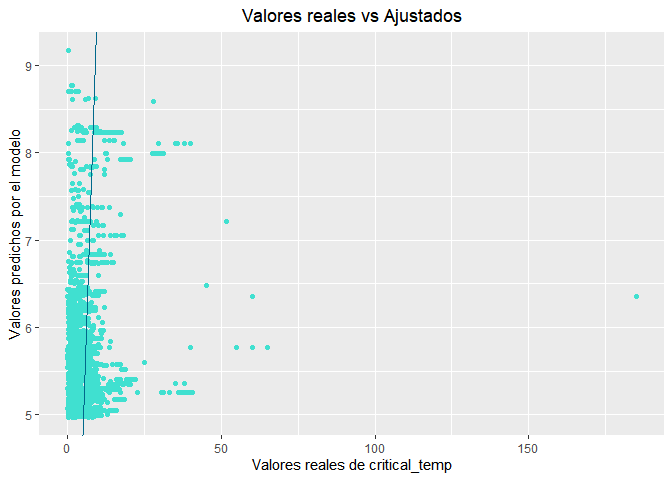

```r
v1 = ndf$critical_temp; v2 = modelos$n2$fitted.values
grafico3 = data.frame(v1, v2)

ggplot(data = grafico3) +
    geom_point(mapping = aes(x = v1, y = v2), color = "turquoise") +
    geom_abline(slope = 1, intercept = 0, color = "deepskyblue4") +
    ggtitle("Valores reales vs Ajustados") +
    theme(plot.title = element_text(hjust = 0.5)) +
    xlab("Valores reales de critical_temp") +
    ylab("Valores predichos por el modelo")
```

> Quedamos a la espera de la presentación 2 para aplicar mejores técnicas (regresión multiple, etc)